# Project: No-shows: Exploring the Characteristics of Patients Who Fail to Show up on Medical Appointments

> By: Lawrence Agyepong

> Email: agyeponglawrence101@gmail.com
- Introduction
- A Brief Review of Related Literature
- Data Wrangling
- Exploratory Data Analysis
- Conclusions

## Introduction

### Background and Problem Statement

In the field of healthcare, no-show refers to patients who fail to show up to scheduled appointments or cancel at the last minute giving the health center no opportunity to fill the appointment slot. This problem of no-shows poses considerable challenges to the effectiveness and quality of healthcare delivery. Lacy et al. (2004) argues that patients who schedule clinic appointments and fail to keep them harm the workflow of health centers.

According to Pfeifer, no-show appointments result in a loss of time and money for the health center and disrupt the continuity of care for patients. Marbouh et al (2020) explain that no-shows can affect the patient’s health condition due to the delay in diagnosis or treatment. Macharia et al. (1992) estimated that an average of 42% of appointments become no-shows. Another study estimates that the healthcare industry loses about $150 billion to patient appointment no shows each year.

The deleterious impact of no-shows on the already resource-constrained healthcare industry has attracted the attention of researchers to investigate the causes and prescribe solutions to arrest the problem. Several studies have identified various factors influencing no-show rates. The frequently cited factors are age, gender, service quality, number of preceding appointments, appointment lead times, and waiting times (see Lacy et al., 2004; Marbouh et al., 2020). According to Glowacka et al. (2009), the reasons for no-shows include difficulty in transportation access, patients forgetting appointments, history of failed appointments, and long waiting times.

The findings of studies on no-shows, like those mentioned above, have influenced many interventions to address the problem. According to Macharia et al. (1992), the most effective intervention has been reminder calls or mailings. Other methods include providing transportation, new patient education, improved scheduling, and other forms of incentives or disincentives to discourage no-shows (see Bean and Talaga, 1992; Smith and Yawn, 1994; Gatrad, 2000). Despite efforts, Lacy et al. (2004) argues that, none of the interventions have been consistently effective. Hence, there is the need to further interrogate the issue to derive alternative insights into the causes and alternative solutions.

### Scope and Data Description

This project is my submission to the Investigating a Dataset Project of Udacity’s Data Analyst Nanodegree. Although the objective of the project is to showcase my understanding of the Data Analysis Process, I intend to use a typical research approach given my research background. Hence, I combine the format prescribed by Udacity with that of a typical scientific paper. The dataset used in this analysis was sourced from Kaggle.com. It contains information from 100k medical appointments in Brazil and is focused on the question of whether or not patients show up for their appointment. It spans the period of Nov 10, 2015, to June 8, 2016.

The following information is included in the dataset:

> 1. PatientId: Identification of a patient
> 2. AppointmentID: Identification of each appointment
> 3. Gender: Male or Female
> 4. AppointmentDay: The day of the actual appointment, when they have to visit the doctor.
> 5. Scheduledday: The day someone called or registered the appointment, this is before appointment of course.
> 6. Age: How old is the patient.
> 7. Neighbourhood: Where the appointment takes place.
> 8. Scholarship: True of False.
> 9. Hipertension: True or False
> 10. Diabetes: True or False
> 11. Alcoholism: True or False
> 12. Handcap: True or False
> 13. SMS_received: 1 or more messages sent to the patient
> 14. No-show: True or False.

Since we are interested in investigating the factors of no-show, the No-show variable is our dependent variable and other variable makes up our independent variables.

To reiterate, the focus of this project is to go through the data analysis process i.e., ask questions, wrangle data, perform EDA, draw conclusions and communicate results. An auxiliary section (i.e., section 2) provides a brief summary of related literature on no-shows. This provides useful input into the empirical relationships between our dependent and independent variables which helps with hypothesis development and informs my assumptions about the data.

### Research Questions

The analysis is guided by the following research questions:

> 1. What demographic characteristics define patients who miss medical appointments?
> 2. What are the health characteristics of patients who miss medical appointments?
> 3. Are patients who receive any form of intervention more likely to show up on their appointments?
> 4. Does waiting time and patients past history of no-show matter?
> 5. What is the most important predictor of no shows?

To address our research questions, especially question 1-3, we group our variables as follows:

> **Dependent variable**: No-show

> **Demographic Characteristic variables**: Gender, Age, Neighborhood

> **Health Characteristics Variables**: Alcoholism, Hipertension, Diabetes, Handcap

> **Intervention variables**: Scholarship, Sms_received

> **Other variables**: PatientId, AppointmentId, AppointmentDay, Scheduledday

Question 4 requires the creation of new features from the existing variables. This will be addressed in the feature engineering part of the data cleaning section.

## A Brief Review of Related Literature

In terms of technique and focus, the extant literature on no-shows in the healthcare industry is diverse. To investigate the topic of no-shows, some studies, such as Lacy et al. (2004), use qualitative approaches such as interviews and focus group discussions. Other studies were more quantitatively oriented, with some examining the topic using advanced data analytics and machine learning approaches (for example Mohammadi et al., 2018). Regardless of the type of research utilized, many studies agree that the problem of no-shows is detrimental to healthcare delivery, necessitating the adoption of innovative solutions to address it.

Using semi-structured interviews with 34 adult patients who came to the clinic for outpatient care, Lacy et al. (2004) investigated the perspectives of patients who were no-shows. Emotions, perceived disrespect, and a lack of knowledge of the scheduling system were the top three reasons for no-shows, according to the study's participants (patients). Other causes for no-shows were logistical challenges with keeping schedules, however, participants did not see these as major concerns. The study discovered that these participants' appointment-making was influenced by immediate symptoms and a need for self-care. Reviewing waiting times and participants' perceptions of personal respect, according to the study, could help minimize no-show rates.

Mohammadi et al. (2018) employed predictive modeling techniques to analyze patient no-shows in community health centers. The study's goal is to build and compare appointment no-show prediction models to gain a better understanding of appointment adherence in underprivileged populations. Patients' adherence to appointments differs between clinics within a healthcare system, according to the researchers. Data analytics results, according to Mohammadi et al, highlight the importance of current clinical and operational data in addressing critical operational and managerial challenges, which could lead to a reduction in no-show rates.

Marbouh et al (2020) investigate the impact of patient no-shows on the quality of healthcare services. The study uses a case study research approach to determine the rate of no-shows and their underlying causes in a radiology department at one of the region's premier hospitals. They discovered that no-shows are common owing to a variety of causes, including patient behavior, financial circumstances, environmental conditions, and scheduling policies. Several recommendations are made in the study to help reduce the frequency of patient no-shows. Patient education, the use of dynamic scheduling policies, and effective appointment reminder systems are all part of this.

Liu et al. (2022) develop an interpretable deep learning-based approach for predicting the risk of no-shows at the time when a medical appointment is first scheduled. They contend that their proposed models, which are based on neural networks and logistic regression, outperform persistent baselines. Patients' previous no-show record is found to be the biggest predictor of appointment no-show in the study. Liu et al. recommend that scheduling high-risk patients' visits during off-peak hours can help prevent no-shows.

## Data Wrangling

### General Properties

```python
# Load the libraries needed for the analysis
import numpy as np
import pandas as pd
import matplotlib.pyplot as plt
import seaborn as sns
%matplotlib inline
```

```python
# Load Data
df = pd.read_csv('medical_appointment.csv')
df.head()
```

|  | PatientId | AppointmentID | Gender | ScheduledDay | AppointmentDay | Age | Neighbourhood | Scholarship | Hipertension | Diabetes | Alcoholism | Handcap | SMS_received | No-show |
| --- | --- | --- | --- | --- | --- | --- | --- | --- | --- | --- | --- | --- | --- | --- |
| 0 | 2.987250e+13 | 5642903 | F | 2016-04-29T18:38:08Z | 2016-04-29T00:00:00Z | 62 | JARDIM DA PENHA | 0 | 1 | 0 | 0 | 0 | 0 | No |
| 1 | 5.589978e+14 | 5642503 | M | 2016-04-29T16:08:27Z | 2016-04-29T00:00:00Z | 56 | JARDIM DA PENHA | 0 | 0 | 0 | 0 | 0 | 0 | No |
| 2 | 4.262962e+12 | 5642549 | F | 2016-04-29T16:19:04Z | 2016-04-29T00:00:00Z | 62 | MATA DA PRAIA | 0 | 0 | 0 | 0 | 0 | 0 | No |
| 3 | 8.679512e+11 | 5642828 | F | 2016-04-29T17:29:31Z | 2016-04-29T00:00:00Z | 8 | PONTAL DE CAMBURI | 0 | 0 | 0 | 0 | 0 | 0 | No |
| 4 | 8.841186e+12 | 5642494 | F | 2016-04-29T16:07:23Z | 2016-04-29T00:00:00Z | 56 | JARDIM DA PENHA | 0 | 1 | 1 | 0 | 0 | 0 | No |

```python
# Cheaking the dimension of the data
df.shape
```

```
(110527, 14)
```

> There are 110,527 observations and 14 features/columns

```python
# Column names
df.columns
```

```
Index(['PatientId', 'AppointmentID', 'Gender', 'ScheduledDay',
       'AppointmentDay', 'Age', 'Neighbourhood', 'Scholarship', 'Hipertension',
       'Diabetes', 'Alcoholism', 'Handcap', 'SMS_received', 'No-show'],
      dtype='object')
```

> **Clean 1**

> We may have to convert the columns names to lower case and replace any hyphens with underscore. This will make typing columns in the analysis easier.

```python
# Inspecting data types
df.dtypes
```

```
PatientId         float64
AppointmentID       int64
Gender             object
ScheduledDay       object
AppointmentDay     object
Age                 int64
Neighbourhood      object
Scholarship         int64
Hipertension        int64
Diabetes            int64
Alcoholism          int64
Handcap             int64
SMS_received        int64
No-show            object
dtype: object
```

> **Clean 2 - Notes on Datatypes**:
> 1. ScheduledDay and AppointmentDay must be converted to datetime format
> 2. No-show may need to be converted to numerical

```python
# Inspecting missing values
df.info()
```

```
<class 'pandas.core.frame.DataFrame'>
RangeIndex: 110527 entries, 0 to 110526
Data columns (total 14 columns):
 #   Column          Non-Null Count   Dtype
---  ------          --------------   -----
 0   PatientId       110527 non-null  float64
 1   AppointmentID   110527 non-null  int64
 2   Gender          110527 non-null  object
 3   ScheduledDay    110527 non-null  object
 4   AppointmentDay  110527 non-null  object
 5   Age             110527 non-null  int64
 6   Neighbourhood   110527 non-null  object
 7   Scholarship     110527 non-null  int64
 8   Hipertension    110527 non-null  int64
 9   Diabetes        110527 non-null  int64
 10  Alcoholism      110527 non-null  int64
 11  Handcap         110527 non-null  int64
 12  SMS_received    110527 non-null  int64
 13  No-show         110527 non-null  object
dtypes: float64(1), int64(8), object(5)
memory usage: 11.8+ MB
```

> **Notes on NA**: There appear to be no missing values

```python
# Number of unique values in each variable
df.nunique()
```

```
PatientId          62299
AppointmentID     110527
Gender                 2
ScheduledDay      103549
AppointmentDay        27
Age                  104
Neighbourhood         81
Scholarship            2
Hipertension           2
Diabetes               2
Alcoholism             2
Handcap                5
SMS_received           2
No-show                2
dtype: int64
```

> **Notes on nunique**
> 1. The number of appointments is about twice the number of patients. This suggests that some patients recorded more than one appointments.
> 2. The appointments took place at 81 different neighborhoods.
> 3. According to the data description, Handcap must have 2 unique values instead of 5. Investigate further.

> **Clean 3**: We may have to drop the Neighbourhood variable since it contains too many unqinue categorical values. Per our research questions, we are likely not to get any useful information from this variable.

```python
df.Handcap.unique()
```

```
array([0, 1, 2, 3, 4], dtype=int64)
```

> Indeed Handcap has 5 unique values. Since no information was provided on it, I will convert it to categorical variable. This is because I do not want to drop it too early to lose information.

> **Clean 4**: Convert Handcap to Categorical values

```python
# Descriptive stats of quantitative variables
df.describe()
```

|  | PatientId | AppointmentID | Age | Scholarship | Hipertension | Diabetes | Alcoholism | Handcap | SMS_received |
| --- | --- | --- | --- | --- | --- | --- | --- | --- | --- |
| count | 1.105270e+05 | 1.105270e+05 | 110527.000000 | 110527.000000 | 110527.000000 | 110527.000000 | 110527.000000 | 110527.000000 | 110527.000000 |
| mean | 1.474963e+14 | 5.675305e+06 | 37.088874 | 0.098266 | 0.197246 | 0.071865 | 0.030400 | 0.022248 | 0.321026 |
| std | 2.560949e+14 | 7.129575e+04 | 23.110205 | 0.297675 | 0.397921 | 0.258265 | 0.171686 | 0.161543 | 0.466873 |
| min | 3.921784e+04 | 5.030230e+06 | -1.000000 | 0.000000 | 0.000000 | 0.000000 | 0.000000 | 0.000000 | 0.000000 |
| 25% | 4.172614e+12 | 5.640286e+06 | 18.000000 | 0.000000 | 0.000000 | 0.000000 | 0.000000 | 0.000000 | 0.000000 |
| 50% | 3.173184e+13 | 5.680573e+06 | 37.000000 | 0.000000 | 0.000000 | 0.000000 | 0.000000 | 0.000000 | 0.000000 |
| 75% | 9.439172e+13 | 5.725524e+06 | 55.000000 | 0.000000 | 0.000000 | 0.000000 | 0.000000 | 0.000000 | 1.000000 |
| max | 9.999816e+14 | 5.790484e+06 | 115.000000 | 1.000000 | 1.000000 | 1.000000 | 1.000000 | 4.000000 | 1.000000 |

> **Notes from Stats Summary**
> 1. **Age**: Average age of patients is 37 years with majority between 18 and 55 years. The minimum age -1 seems absurd so investigate further. A maximum age of 115 also require investigation since it indicates the existence of outliers.
> 2. Given that all the other variables are between 0 and 1, we may have to scale the Age variable to 0-1
> 3. 19.72% have Hipertension, 7.19% are Diabetic, 3.04% battle with Alcoholism
> 4. 9.82% have Scholarship, 32.1% received one or more Sms messages

```python
# Investigating the Age variable
# Show observations with age of less than 0
abnorm_age = df.query('Age < 0')
abnorm_age
```

|  | PatientId | AppointmentID | Gender | ScheduledDay | AppointmentDay | Age | Neighbourhood | Scholarship | Hipertension | Diabetes | Alcoholism | Handcap | SMS_received | No-show |
| --- | --- | --- | --- | --- | --- | --- | --- | --- | --- | --- | --- | --- | --- | --- |
| 99832 | 4.659432e+14 | 5775010 | F | 2016-06-06T08:58:13Z | 2016-06-06T00:00:00Z | -1 | ROMÃO | 0 | 0 | 0 | 0 | 0 | 0 | No |

> Since having a negative age is not normal, I will drop the observation

|  | Age |
| --- | --- |
| count | 110527.000000 |
| mean | 37.088874 |
| std | 23.110205 |
| min | -1.000000 |
| 25% | 18.000000 |
| 50% | 37.000000 |
| 75% | 55.000000 |
| max | 115.000000 |

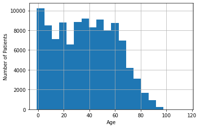

```python
# Checking for outlier in Age
# Create a histogram
df.Age.hist(bins=20)
plt.xlabel('Age')
plt.ylabel('Number of Patients')
df[['Age']].describe()
```

> We observe that some patients are older than 100 years! Such patients are not representative of the population and may bias the results of the analysis.

> **Clean 5: Drop patients with age greater than 100 years and less than 0 years**

```python
# Descriptive stats of categorical variables
df.describe(include=['O'])
```

|  | Gender | ScheduledDay | AppointmentDay | Neighbourhood | No-show |
| --- | --- | --- | --- | --- | --- |
| count | 110527 | 110527 | 110527 | 110527 | 110527 |
| unique | 2 | 103549 | 27 | 81 | 2 |
| top | F | 2016-05-06T07:09:54Z | 2016-06-06T00:00:00Z | JARDIM CAMBURI | No |
| freq | 71840 | 24 | 4692 | 7717 | 88208 |

> 1. Majority of patients are female
> 2. Most frequent hospital location (neighbourhood) is JARDIM CAMBURI
> 3. Majority of the patients showed up on their appointments

```python
# Inspecting data for duplicated rows
df.duplicated().sum()
```

```
0
```

> We found no duplicated rows/observations

### Data Cleaning

In this part, we will address the data problems identified in the previous part. These are:

> 1. Convert the columns names to lower case and replace any hyphens with underscore.
> 2. ScheduledDay and AppointmentDay must be converted to datetime format
> 3. Convert No-show to numerical
> 4. Convert Handcap to categorical
> 5. Drop row with age outliers
> 6. Drop irrelevant columns

```python
# Create a copy to the dataset
df1 = df.copy()
```

#### Clean Column names

> *Convert the columns names to lower case and replace any hyphens with underscore.*

```python
# Convert column names to lower case
df1.rename(columns=lambda x: x.lower(), inplace=True)
```

```python
# Replace hyphen with underscore in no-show
df1.columns = [
    'patientid', 'appointmentid', 'gender', 'scheduledday', 'appointmentday',
    'age', 'neighbourhood', 'scholarship', 'hipertension', 'diabetes',
    'alcoholism', 'handcap', 'sms_received', 'no_show'
]
```

```python
df1.columns
```

```
Index(['patientid', 'appointmentid', 'gender', 'scheduledday',
       'appointmentday', 'age', 'neighbourhood', 'scholarship', 'hipertension',
       'diabetes', 'alcoholism', 'handcap', 'sms_received', 'no_show'],
      dtype='object')
```

#### Fixing Data types

> 1. *ScheduledDay and AppointmentDay must be converted to datetime format*

```python
# extract only the date string
pattern = "((\d\d\d\d)-(\d\d)-(\d\d))"
df1['scheduledday'] = df1['scheduledday'].str.extract(pattern)[0]
df1['appointmentday'] = df1['appointmentday'].str.extract(pattern)[0]

# Convert to string to Datetime
df1['scheduledday'] = pd.to_datetime(df1['scheduledday'])
df1['appointmentday'] = pd.to_datetime(df1['appointmentday'])
```

```python
# Verify the changes
df1.info()
```

```
<class 'pandas.core.frame.DataFrame'>
RangeIndex: 110527 entries, 0 to 110526
Data columns (total 14 columns):
 #   Column          Non-Null Count   Dtype
---  ------          --------------   -----
 0   patientid       110527 non-null  float64
 1   appointmentid   110527 non-null  int64
 2   gender          110527 non-null  object
 3   scheduledday    110527 non-null  datetime64[ns]
 4   appointmentday  110527 non-null  datetime64[ns]
 5   age             110527 non-null  int64
 6   neighbourhood   110527 non-null  object
 7   scholarship     110527 non-null  int64
 8   hipertension    110527 non-null  int64
 9   diabetes        110527 non-null  int64
 10  alcoholism      110527 non-null  int64
 11  handcap         110527 non-null  int64
 12  sms_received    110527 non-null  int64
 13  no_show         110527 non-null  object
dtypes: datetime64[ns](2), float64(1), int64(8), object(3)
memory usage: 11.8+ MB
```

> scheduledday and appointmentday are now datetime
> 1. *Convert No-show to numerical*

> 1 if the Patient did not show up, 0 otherwise

```python
# Replace No with 0 and Yes with 1
map_no_show = {'No': 0, 'Yes': 1}
df1.no_show.replace(map_no_show, inplace=True)
df1.no_show.value_counts()
```

```
0    88208
1    22319
Name: no_show, dtype: int64
```

> 1. *Convert Handcap to categorical*

```python
# Replace numbers with string
map_handcap = {0: '0', 1: '1', 2: '2', 3: '3', 4: '4'}
df1.handcap.replace(map_handcap, inplace=True)
```

#### Dropping rows and columns

> 1. *Drop row with negative age*

```python
# Drop outliers
age_neg = df1[df1.age < 0].index
age_100 = df1[df1.age > 100].index
df1.drop(index=age_neg, inplace=True)
df1.drop(index=age_100, inplace=True)
```

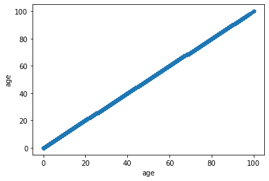

```python
# Detecting outliers Age using scatterplot
df1.plot(x='age', y='age', kind='scatter');
```

> We have dealt with outliers in the age variable
> 1. *Drop irrelevant columns (This will be done later after featuring engineering)*

### Feature Engineering

```python
# Calculating Lead time
lead_time = df1['appointmentday'] - df1['scheduledday']
lead_time.head()
```

```
0   0 days
1   0 days
2   0 days
3   0 days
4   0 days
dtype: timedelta64[ns]
```

> Our lead_time variable is in the timedelta64 format. For the purpose of our analysis, we need to extract only the number of days in integer format.

```python
# Extract only the number of days in int
lead_time = lead_time.dt.days
lead_time.head()
```

```
0    0
1    0
2    0
3    0
4    0
dtype: int64
```

|  | lead_time |
| --- | --- |
| count | 110519.000000 |
| mean | 10.183887 |
| std | 15.255169 |
| min | -6.000000 |
| 25% | 0.000000 |
| 50% | 4.000000 |
| 75% | 15.000000 |
| max | 179.000000 |

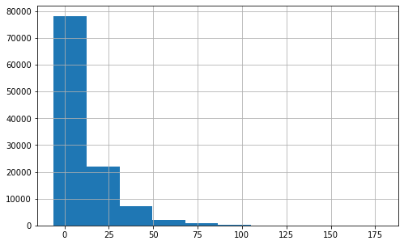

```python
# inspect lead time
lead_time.hist(bins=10, figsize=(8, 5))
pd.DataFrame(lead_time, columns=['lead_time']).describe()
```

> From the distribution of the data, I suspect issues of outliers or strange observations. Let's investigate further.

> We observe a highly right-skewed lead times with a minimum of -6 max of 179. I suspect outlier problems.

> It is interesting that we observe negative lead times. It literally suggests that some patients had appointment days before scheduling...??? This doesn't make sense!

> Let's investigate!

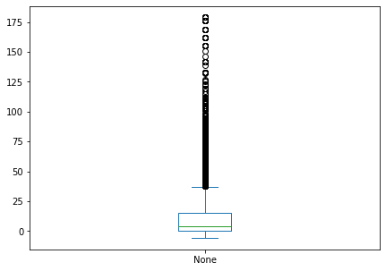

```python
# Visualize with a boxplot to inspect outliers
lead_time.plot(kind='box', figsize=(7, 5));
```

> Indeed there are outliers. Some patients had to waits for as long as 6 months! However, I choose to treat the outliers different this time because I believe it will be interesting to learn about the characteristics of such patients.

> Instead of dropping outliers with long waiting times, I will rather create a categorial variable for lead times. This will help make the use of the data

```python
# add lead time to df1 to investigate the characteristic of outliers
df1['lead_time'] = lead_time
df1.head()
```

|  | patientid | appointmentid | gender | scheduledday | appointmentday | age | neighbourhood | scholarship | hipertension | diabetes | alcoholism | handcap | sms_received | no_show | lead_time |
| --- | --- | --- | --- | --- | --- | --- | --- | --- | --- | --- | --- | --- | --- | --- | --- |
| 0 | 2.987250e+13 | 5642903 | F | 2016-04-29 | 2016-04-29 | 62 | JARDIM DA PENHA | 0 | 1 | 0 | 0 | 0 | 0 | 0 | 0 |
| 1 | 5.589978e+14 | 5642503 | M | 2016-04-29 | 2016-04-29 | 56 | JARDIM DA PENHA | 0 | 0 | 0 | 0 | 0 | 0 | 0 | 0 |
| 2 | 4.262962e+12 | 5642549 | F | 2016-04-29 | 2016-04-29 | 62 | MATA DA PRAIA | 0 | 0 | 0 | 0 | 0 | 0 | 0 | 0 |
| 3 | 8.679512e+11 | 5642828 | F | 2016-04-29 | 2016-04-29 | 8 | PONTAL DE CAMBURI | 0 | 0 | 0 | 0 | 0 | 0 | 0 | 0 |
| 4 | 8.841186e+12 | 5642494 | F | 2016-04-29 | 2016-04-29 | 56 | JARDIM DA PENHA | 0 | 1 | 1 | 0 | 0 | 0 | 0 | 0 |

```python
# Lets look at the characteristics of patients with negative lead_times
df1[df1.lead_time < 0]
```

|  | patientid | appointmentid | gender | scheduledday | appointmentday | age | neighbourhood | scholarship | hipertension | diabetes | alcoholism | handcap | sms_received | no_show | lead_time |
| --- | --- | --- | --- | --- | --- | --- | --- | --- | --- | --- | --- | --- | --- | --- | --- |
| 27033 | 7.839273e+12 | 5679978 | M | 2016-05-10 | 2016-05-09 | 38 | RESISTÊNCIA | 0 | 0 | 0 | 0 | 1 | 0 | 1 | -1 |
| 55226 | 7.896294e+12 | 5715660 | F | 2016-05-18 | 2016-05-17 | 19 | SANTO ANTÔNIO | 0 | 0 | 0 | 0 | 1 | 0 | 1 | -1 |
| 64175 | 2.425226e+13 | 5664962 | F | 2016-05-05 | 2016-05-04 | 22 | CONSOLAÇÃO | 0 | 0 | 0 | 0 | 0 | 0 | 1 | -1 |
| 71533 | 9.982316e+14 | 5686628 | F | 2016-05-11 | 2016-05-05 | 81 | SANTO ANTÔNIO | 0 | 0 | 0 | 0 | 0 | 0 | 1 | -6 |
| 72362 | 3.787482e+12 | 5655637 | M | 2016-05-04 | 2016-05-03 | 7 | TABUAZEIRO | 0 | 0 | 0 | 0 | 0 | 0 | 1 | -1 |

> There are five observations with negative lead_times all of which didn't show up. I assume there were errors in there input and therfore I will drop them.

```python
# drop observations with negative lead times
df1 = df1[df1.lead_time >= 0]
df1.head()
```

|  | patientid | appointmentid | gender | scheduledday | appointmentday | age | neighbourhood | scholarship | hipertension | diabetes | alcoholism | handcap | sms_received | no_show | lead_time |
| --- | --- | --- | --- | --- | --- | --- | --- | --- | --- | --- | --- | --- | --- | --- | --- |
| 0 | 2.987250e+13 | 5642903 | F | 2016-04-29 | 2016-04-29 | 62 | JARDIM DA PENHA | 0 | 1 | 0 | 0 | 0 | 0 | 0 | 0 |
| 1 | 5.589978e+14 | 5642503 | M | 2016-04-29 | 2016-04-29 | 56 | JARDIM DA PENHA | 0 | 0 | 0 | 0 | 0 | 0 | 0 | 0 |
| 2 | 4.262962e+12 | 5642549 | F | 2016-04-29 | 2016-04-29 | 62 | MATA DA PRAIA | 0 | 0 | 0 | 0 | 0 | 0 | 0 | 0 |
| 3 | 8.679512e+11 | 5642828 | F | 2016-04-29 | 2016-04-29 | 8 | PONTAL DE CAMBURI | 0 | 0 | 0 | 0 | 0 | 0 | 0 | 0 |
| 4 | 8.841186e+12 | 5642494 | F | 2016-04-29 | 2016-04-29 | 56 | JARDIM DA PENHA | 0 | 1 | 1 | 0 | 0 | 0 | 0 | 0 |

```python
# create another copy of the dataframe
df2 = df1.copy()
```

```python
# Creating a new variable with lead_time being grouped
# Specifying the range of values to be replaced and the new labels
bin_lead_time = [
    np.arange(0, 1),
    np.arange(1, 8),
    np.arange(8, 32),
    np.arange(32, 92),
    np.arange(92, 180)
]
new_label = [
    'Same Day', 'Within 1week', '1wk to 1month', '1 to 3months', '3 to 6months'
]

# Create a new column for lead_time
df2['new_lead_time'] = df1.lead_time

# Replace the integers with our new groupings
for i in range(len(new_label)):
    df2.new_lead_time.replace(to_replace=bin_lead_time[i],
                              value=new_label[i],
                              inplace=True)

df2.head()
```

|  | patientid | appointmentid | gender | scheduledday | appointmentday | age | neighbourhood | scholarship | hipertension | diabetes | alcoholism | handcap | sms_received | no_show | lead_time | new_lead_time |
| --- | --- | --- | --- | --- | --- | --- | --- | --- | --- | --- | --- | --- | --- | --- | --- | --- |
| 0 | 2.987250e+13 | 5642903 | F | 2016-04-29 | 2016-04-29 | 62 | JARDIM DA PENHA | 0 | 1 | 0 | 0 | 0 | 0 | 0 | 0 | Same Day |
| 1 | 5.589978e+14 | 5642503 | M | 2016-04-29 | 2016-04-29 | 56 | JARDIM DA PENHA | 0 | 0 | 0 | 0 | 0 | 0 | 0 | 0 | Same Day |
| 2 | 4.262962e+12 | 5642549 | F | 2016-04-29 | 2016-04-29 | 62 | MATA DA PRAIA | 0 | 0 | 0 | 0 | 0 | 0 | 0 | 0 | Same Day |
| 3 | 8.679512e+11 | 5642828 | F | 2016-04-29 | 2016-04-29 | 8 | PONTAL DE CAMBURI | 0 | 0 | 0 | 0 | 0 | 0 | 0 | 0 | Same Day |
| 4 | 8.841186e+12 | 5642494 | F | 2016-04-29 | 2016-04-29 | 56 | JARDIM DA PENHA | 0 | 1 | 1 | 0 | 0 | 0 | 0 | 0 | Same Day |

```python
# inspect our new variable for correctness
df2.new_lead_time.value_counts()
```

```
Same Day         38560
Within 1week     32182
1wk to 1month    30067
1 to 3months      9544
3 to 6months       161
Name: new_lead_time, dtype: int64
```

```python
# Now lets create the past_no_show variable
# Recall Past no-show: the number of no-shows for a given patient
df2['num_past_noshow'] = df2.groupby('patientid')['no_show'].apply(
    lambda x: x.cumsum())
```

```python
df2.head()
```

|  | patientid | appointmentid | gender | scheduledday | appointmentday | age | neighbourhood | scholarship | hipertension | diabetes | alcoholism | handcap | sms_received | no_show | lead_time | new_lead_time | num_past_noshow |
| --- | --- | --- | --- | --- | --- | --- | --- | --- | --- | --- | --- | --- | --- | --- | --- | --- | --- |
| 0 | 2.987250e+13 | 5642903 | F | 2016-04-29 | 2016-04-29 | 62 | JARDIM DA PENHA | 0 | 1 | 0 | 0 | 0 | 0 | 0 | 0 | Same Day | 0 |
| 1 | 5.589978e+14 | 5642503 | M | 2016-04-29 | 2016-04-29 | 56 | JARDIM DA PENHA | 0 | 0 | 0 | 0 | 0 | 0 | 0 | 0 | Same Day | 0 |
| 2 | 4.262962e+12 | 5642549 | F | 2016-04-29 | 2016-04-29 | 62 | MATA DA PRAIA | 0 | 0 | 0 | 0 | 0 | 0 | 0 | 0 | Same Day | 0 |
| 3 | 8.679512e+11 | 5642828 | F | 2016-04-29 | 2016-04-29 | 8 | PONTAL DE CAMBURI | 0 | 0 | 0 | 0 | 0 | 0 | 0 | 0 | Same Day | 0 |
| 4 | 8.841186e+12 | 5642494 | F | 2016-04-29 | 2016-04-29 | 56 | JARDIM DA PENHA | 0 | 1 | 1 | 0 | 0 | 0 | 0 | 0 | Same Day | 0 |

> **Now we will drop irrelevant columns**

```python
df2.columns
```

```
Index(['patientid', 'appointmentid', 'gender', 'scheduledday',
       'appointmentday', 'age', 'neighbourhood', 'scholarship', 'hipertension',
       'diabetes', 'alcoholism', 'handcap', 'sms_received', 'no_show',
       'lead_time', 'new_lead_time', 'num_past_noshow'],
      dtype='object')
```

```python
drop_colums = [
    'patientid', 'appointmentid', 'scheduledday', 'appointmentday',
    'neighbourhood'
]
df2.drop(drop_colums, axis=1, inplace=True)
```

```python
# Lets confirm our columns
df2.columns
```

```
Index(['gender', 'age', 'scholarship', 'hipertension', 'diabetes',
       'alcoholism', 'handcap', 'sms_received', 'no_show', 'lead_time',
       'new_lead_time', 'num_past_noshow'],
      dtype='object')
```

```python
df2.head()
```

|  | gender | age | scholarship | hipertension | diabetes | alcoholism | handcap | sms_received | no_show | lead_time | new_lead_time | num_past_noshow |
| --- | --- | --- | --- | --- | --- | --- | --- | --- | --- | --- | --- | --- |
| 0 | F | 62 | 0 | 1 | 0 | 0 | 0 | 0 | 0 | 0 | Same Day | 0 |
| 1 | M | 56 | 0 | 0 | 0 | 0 | 0 | 0 | 0 | 0 | Same Day | 0 |
| 2 | F | 62 | 0 | 0 | 0 | 0 | 0 | 0 | 0 | 0 | Same Day | 0 |
| 3 | F | 8 | 0 | 0 | 0 | 0 | 0 | 0 | 0 | 0 | Same Day | 0 |
| 4 | F | 56 | 0 | 1 | 1 | 0 | 0 | 0 | 0 | 0 | Same Day | 0 |

```python
# Let's save our cleaned data
df_clean = df2.copy()
df_clean.to_csv('df_clean.csv', index=False)
```

```python
df_clean.info()
```

```
<class 'pandas.core.frame.DataFrame'>
Int64Index: 110514 entries, 0 to 110526
Data columns (total 12 columns):
 #   Column           Non-Null Count   Dtype
---  ------           --------------   -----
 0   gender           110514 non-null  object
 1   age              110514 non-null  int64
 2   scholarship      110514 non-null  int64
 3   hipertension     110514 non-null  int64
 4   diabetes         110514 non-null  int64
 5   alcoholism       110514 non-null  int64
 6   handcap          110514 non-null  object
 7   sms_received     110514 non-null  int64
 8   no_show          110514 non-null  int64
 9   lead_time        110514 non-null  int64
 10  new_lead_time    110514 non-null  object
 11  num_past_noshow  110514 non-null  int64
dtypes: int64(9), object(3)
memory usage: 11.0+ MB
```

> Our data is ready to be analyzed!

> Let's draw some insights!!!

## Exploratory Data Analysis

Now that the data is clean, I will move on the address the research questions.

### What demographic characteristics define patients who miss their medical appointments?

This question requires investigating the relationship between the **no_show** variable and the demographic variables i.e., **gender and age**.

#### No Show and Gender

```python
# Check the distribution of the variables
print('No Show')
print(100 * df_clean.no_show.value_counts() / len(df_clean))
print('-' * 50)
print('Gender')
print(100 * df_clean.gender.value_counts() / len(df_clean))
```

```
No Show
0    79.811608
1    20.188392
Name: no_show, dtype: float64
--------------------------------------------------
Gender
F    64.995385
M    35.004615
Name: gender, dtype: float64
```

> 65% of the patients in the sample are female

```python
# Comparing the means of no_shows for gender
df_clean.groupby('gender')['no_show'].mean()
```

```
gender
F    0.203093
M    0.199638
Name: no_show, dtype: float64
```

We observe that means of female and male no_shows are approximately the same (0.2). This suggests that there is no relationship between the two variables. Let's visualize this on a bargraph.

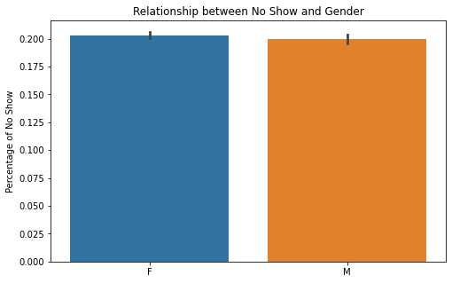

```python
# Plot the relationship on a bargraph
plt.figure(figsize=(8, 5))
sns.barplot(x='gender', y='no_show', data=df_clean)
plt.title('Relationship between No Show and Gender')
plt.ylabel('Percentage of No Show')
plt.xlabel('');
```

Although we notice a small difference between the average no_show, this difference is negligible.

#### No Show and Age

```python
# Correlation between no_show and age
correlation_coeff = df_clean.no_show.corr(df_clean.age)
print('Correlation Coefficient between no_show and age is: ',
      correlation_coeff)
```

```
Correlation Coefficient between no_show and age is:  -0.06046867943085962
```

We find a negative weak correlation between age and no_show. This suggests that no_show is less prevalent among older patients. Let's investigate further.

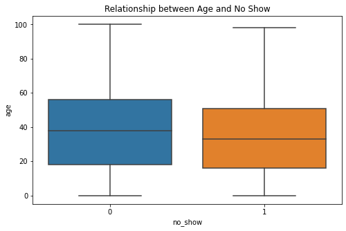

```python
# plot no_show and age on boxplot
plt.figure(figsize=(8, 5))
sns.boxplot(data=df_clean, x='no_show', y='age')
plt.title('Relationship between Age and No Show');
```

From the boxplot, we observe that the average age among patients who missed appointments is lower than those who did not. However, we also observe significant overlap of ages between the two groups (remember 1 = no_show, 0 = show)

### What are the health characteristics of patients who miss their medical appointments?

Here, we analyze the relationship between no_show variable and alcoholism, hipertension, diabetes, and handcap

```python
# Create a list containing the health variables
h_variables = ['hipertension', 'diabetes', 'alcoholism', 'handcap']
```

```python
# Group the heatlh variables by no-show and find their means
df_clean.groupby('no_show')[['hipertension', 'diabetes', 'alcoholism'
                             ]].mean() * 100
```

| no_show | hipertension | diabetes | alcoholism |
| --- | --- | --- | --- |
| 0 | 20.439214 | 7.384103 | 3.041847 |
| 1 | 16.906459 | 6.409394 | 3.034378 |

```python
# Create a function that plots the relationship between the variables and no-show on a bargraph
def bargraphs(columns, data):
    for i in columns:
        plt.figure(figsize=(8, 5))
        sns.barplot(y='no_show', x=i, data=data)
        plt.title('Relationship between No Show and ' + i)
        plt.ylabel('Percentage of No Show')
        plt.xlabel(i)
```

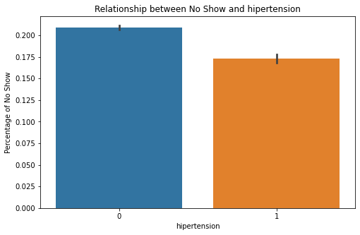

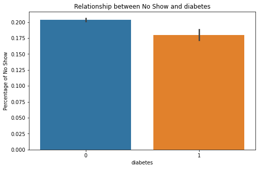

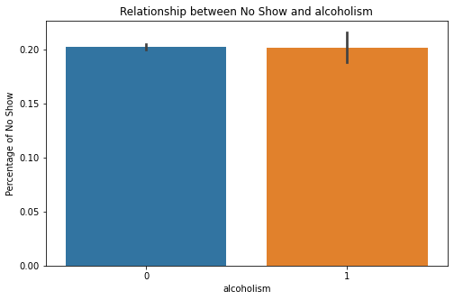

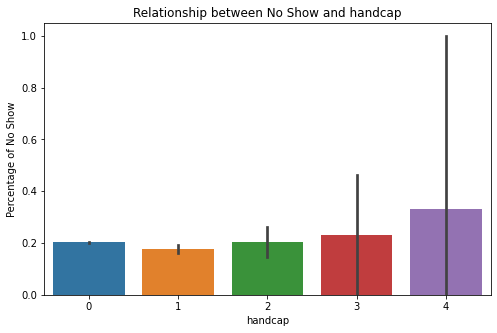

```python
# Create barplots for the relationship between the health variables and no-show
bargraphs(h_variables, df_clean)
```

From the graph, we make the following observations;

> No show is higher among patients without hipertension and diabetes.

> There is no obvious difference in no_show between alcoholics and non alcoholics.

> No show is high at high levels of handcap.

### Are patients who receive any form of intervention more likely to show up on their appointments?

The variables of interest here are no_show, sms_received, and scholarship

```python
df_clean.head()
```

|  | gender | age | scholarship | hipertension | diabetes | alcoholism | handcap | sms_received | no_show | lead_time | new_lead_time | num_past_noshow |
| --- | --- | --- | --- | --- | --- | --- | --- | --- | --- | --- | --- | --- |
| 0 | F | 62 | 0 | 1 | 0 | 0 | 0 | 0 | 0 | 0 | Same Day | 0 |
| 1 | M | 56 | 0 | 0 | 0 | 0 | 0 | 0 | 0 | 0 | Same Day | 0 |
| 2 | F | 62 | 0 | 0 | 0 | 0 | 0 | 0 | 0 | 0 | Same Day | 0 |
| 3 | F | 8 | 0 | 0 | 0 | 0 | 0 | 0 | 0 | 0 | Same Day | 0 |
| 4 | F | 56 | 0 | 1 | 1 | 0 | 0 | 0 | 0 | 0 | Same Day | 0 |

```python
# Group the intervention variables by no-show and find their means
df_clean.groupby('no_show')[['scholarship', 'sms_received']].mean() * 100
```

| no_show | scholarship | sms_received |
| --- | --- | --- |
| 0 | 9.390837 | 29.133930 |
| 1 | 11.554838 | 43.852808 |

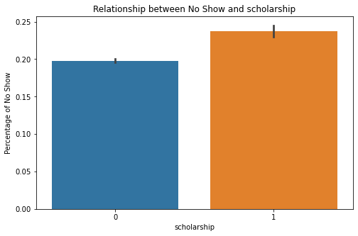

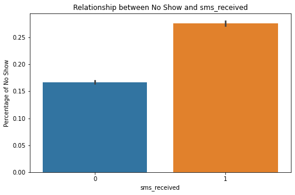

```python
# Create barplots for the relationship between the intervention variables and no-show
interven_vars = ['scholarship',
                 'sms_received']  # list of intervention variables

bargraphs(interven_vars, df_clean)  #create barplots
```

> We observe that no show higher among patients with scholarship than non scholarship patients

> Also, no show is higher among patients who received sms reminders than those who did not receive any reminder.

### Does waiting time and patients past history of no shows matter?

We gathered from the literature that waiting time (in our case lead time) and patients' past record of missed appointments are strong predictors of no_show. Here, we investigate both claims.

```python
df_clean[['no_show', 'lead_time', 'num_past_noshow']].corr()
```

|  | no_show | lead_time | num_past_noshow |
| --- | --- | --- | --- |
| no_show | 1.000000 | 0.186312 | 0.582602 |
| lead_time | 0.186312 | 1.000000 | 0.061351 |
| num_past_noshow | 0.582602 | 0.061351 | 1.000000 |

The correlation matrix provides us some indication of a positive relationship between no_show and lead_time and num_past_noshow. Lets investigate further to uncover more insights.

```python
# Compare averages of lead_time and num_past_noshow between no_show groups
df_clean.groupby('no_show')[['lead_time', 'num_past_noshow']].mean()
```

| no_show | lead_time | num_past_noshow |
| --- | --- | --- |
| 0 | 8.754963 | 0.176853 |
| 1 | 15.835642 | 1.343015 |

> On average, patients who did not show up have higher lead_time (approximately 16 days) than those who show up(approximately 8 days).

> Also, patients who did not show up have higher past missed appointments than those who show up.

> Lets visualize this.

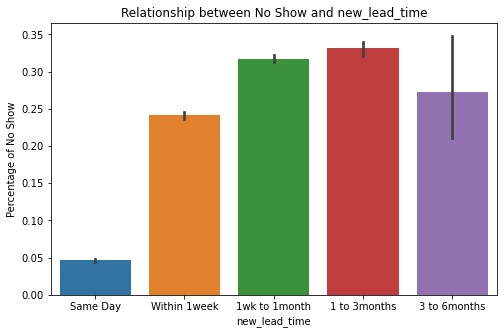

```python
# Plot barplox for categorical lead_times
new_lead_time = ['new_lead_time']

bargraphs(new_lead_time, df_clean)
```

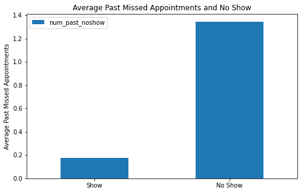

```python
# Plot avg num_past_noshow againt no_show
df_clean.groupby('no_show')[['num_past_noshow']].mean().plot(kind='bar',
                                                             figsize=(8, 5))
plt.xticks(ticks=[0, 1], labels=['Show', 'No Show'], rotation=0)
plt.xlabel('')
plt.ylabel('Average Past Missed Appointments')
plt.title('Average Past Missed Appointments and No Show');
```

On average, patients who do not show up have higher past missed appointments compared to those who show up.

### What is the most important predictor of no shows?

So far, we have seen how the various variables are related to no_show. Now we want to find out which of the variables can best predict no_show. Although not sufficient, comparing correlation coefficients can give useful insights.

```python
# make a new copy of data
df_pre = df_clean.copy()
```

```python
# convert gender into int in order to get the correlation coefficient
df_pre.gender.replace('F', 1, inplace=True)  # 1 if Female
df_pre.gender.replace('M', 0, inplace=True)  # 0 if Male
```

```python
# drop irrelevant columns
df_pre.drop(['handcap', 'new_lead_time'], axis=1, inplace=True)
df_pre.columns
```

```
Index(['gender', 'age', 'scholarship', 'hipertension', 'diabetes',
       'alcoholism', 'sms_received', 'no_show', 'lead_time',
       'num_past_noshow'],
      dtype='object')
```

```python
# Correlation
df_pre.corr()['no_show']
```

```
gender             0.004106
age               -0.060469
scholarship        0.029180
hipertension      -0.035636
diabetes          -0.015149
alcoholism        -0.000175
sms_received       0.126547
no_show            1.000000
lead_time          0.186312
num_past_noshow    0.582602
Name: no_show, dtype: float64
```

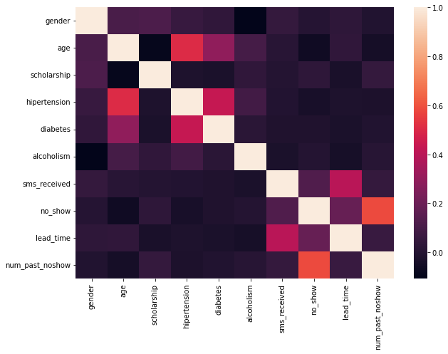

```python
# Correlation Heatmap
plt.figure(figsize=(10, 7))
sns.heatmap(df_pre.corr());
```

> The heatmap above shows the relationship between the variables in the data. We are interested in the the correlation between no_show and the other variables in the study.

> We observe that among the variables included in this analysis, past missed appointments is the strongest predictor of no_shows. Num_past_noshow has a positive correlation (0.58) with no_show.

## Conclusion

The objective of this analysis was to employ the data analysis process to investigate the reasons why patients who fail to show up to scheduled appointments or cancel at the last minute giving the health center no opportunity to fill the appointment slot. I used data on medical appointments in Brazil for the period Nov 10, 2015, to June 8, 2016. Below, I present a summary of the finding of this analysis organized by the five research questions.

### Summary of Finding

**RQ1: What demographic characteristics define patients who miss their medical appointments?**

> • On average, the percentage of patients who do not show up for appointments are approximately the same among females and males i.e., 20.3% for females and 19.96% for males.

> • There is a negative association between no-show and age. This suggests that no-show is more prevalent among younger patients. However, this association is weak i.e., the correlation coefficient is -0.06.

**RQ2: What are the health characteristics of patients who miss their medical appointments?**

> • Among the patients who did not show up, 16.9% have hypertension, 6.41% have diabetes, and 3.03% deal with alcoholism.

> • Of those who show up, 20.44% have hypertension, 7.38% have diabetes, and 3.04% deal with alcoholism.

> • While we observe a difference in the prevalence of no-shows among patients with hypertension and diabetes, there is no difference in no-shows between alcoholics and non-alcoholics.

> • Also, the analysis shows that higher levels of handcap is associated with a high percentage of no-show.

**RQ3: Are patients who receive any form of intervention more likely to show up for their appointments?**

> • This finding is interesting as it contradicts the idea that patients do not show up because of forgetfulness and that interventions such as SMS reminders will encourage showing up.

**RQ4: Does waiting time and patients' history of no shows matter?**

> • On average, patients who did not show up have a higher lead-time (approximately 16 days) than those who show up (approximately 8 days).

> • Also, patients who did not show up have higher past missed appointments than those who show up, on average.

**RQ5: What is the most important predictor of no-shows?**

> • Among the variables included in this analysis, the number of past missed appointments is the strongest predictor of no-shows.

> • The number of past no-shows of patients has a positive and moderate correlation with no-shows i.e., a correlation coefficient of 0.58.

### Limitation of the Study

We have achieved the objective of this analysis and answered the research questions. However, there are some drawbacks to this work. A major limitation of this analysis is that, I did not perform statistical analysis to support the relationships discovered in the analysis. As request, I cannot make inferences about the data. Also, other important variables such as income status and distance of commute to the hospitals would have provided interesting insights. Furthermore, advancing the analysis by including machine learning techniques to predicts no-shows would have improved the relevance of this project. In the immediate future, I intend to revise this project by address the aforementioned limitations.

## References

### Research Papers/Journals

> Bean, A. G., & Talaga, J. (1992). Appointment breaking: causes and solutions. Marketing Health Services, 12(4), 14.

> Gatrad, A. R. (2000). A completed audit to reduce hospital outpatients non-attendance rates. Archives of Disease in Childhood, 82(1), 59-61.

> Glowacka, K. J., Henry, R. M., & May, J. H. (2009). A hybrid data mining/simulation approach for modelling outpatient no-shows in clinic scheduling. Journal of the Operational Research Society, 60(8), 1056-1068.

> Lacy, N. L., Paulman, A., Reuter, M. D., & Lovejoy, B. (2004). Why we don’t come: patient perceptions on no-shows. The Annals of Family Medicine, 2(6), 541-545.

> Liu, D., Shin, W. Y., Sprecher, E., Conroy, K., Santiago, O., Wachtel, G., & Santillana, M. (2022). Machine learning approaches to predicting no-shows in pediatric medical appointment. NPJ digital medicine, 5(1), 1-11.

> Macharia, W. M., Leon, G., Rowe, B. H., Stephenson, B. J., & Haynes, R. B. (1992). An overview of interventions to improve compliance with appointment keeping for medical services. Jama, 267(13), 1813-1817.

> Marbouh, D., Khaleel, I., Al Shanqiti, K., Al Tamimi, M., Simsekler, M. C. E., Ellahham, S., ... & Alibazoglu, H. (2020). Evaluating the impact of patient no-shows on service quality. Risk management and healthcare policy, 13, 509.

> Mohammadi, I., Wu, H., Turkcan, A., Toscos, T., & Doebbeling, B. N. (2018). Data analytics and modeling for appointment no-show in community health centers. Journal of primary care & community health, 9, 2150132718811692.

> Smith, C. M., & Yawn, B. P. (1994). Factors associated with appointment keeping in a family practice residency clinic. Journal of Family Practice, 38(1), 25-29.

### Datasource and other resources

> 1. Datasource: https://www.kaggle.com/datasets/joniarroba/noshowappointments
> 2. Time Deltas Docs: https://pandas.pydata.org/docs/user_guide/timedeltas.html
> 3. Converting column to datetime: https://www.geeksforgeeks.org/convert-the-column-type-from-string-to-datetime-format-in-pandas-dataframe/
> 4. Working with Markdowns : https://stackoverflow.com/questions/35077507/how-to-right-align-and-justify-align-in-markdown